# Assignment 2: Inspecting and Comparing Embeddings

*Use this notebook to complete the sentence similarity and embedding visualization tasks.*

```python
!git clone https://github.com/Anushka-De/stat359.git
```

```
Cloning into 'stat359'...
remote: Enumerating objects: 125, done.
remote: Counting objects: 100% (74/74), done.
remote: Compressing objects: 100% (59/59), done.
remote: Total 125 (delta 56), reused 16 (delta 15), pack-reused 51 (from 1)
Receiving objects: 100% (125/125), 1008.26 KiB | 10.61 MiB/s, done.
Resolving deltas: 100% (64/64), done.
```

```python
%cd stat359/student/Assignment_2
!ls
```

```
/content/stat359/student/Assignment_2
data.py           handout.html            pytorch_train_word2vec.py
download_gensim_model.py  inspect_embeddings.ipynb    README.md
gensim_train_word2vec.py  pytorch_show_embeddings.py
```

```python
!pip install -q numpy pandas gensim torch scikit-learn matplotlib ipywidgets nltk tqdm datasets
```

```
   ━━━━━━━━━━━━━━━━━━━━━━━━━━━━━━━━━━━━━━━━ 27.9/27.9 MB 82.9 MB/s eta 0:00:00

   ━━━━━━━━━━━━━━━━━━━━━━━━━━━━━━━━━━━━━━━━ 1.6/1.6 MB 89.8 MB/s eta 0:00:00
```

```python
!python data.py
```

```
[==================================================] 100.0% 31.6/31.6MB downloaded
Number of sentences: 1701
First sample: ['anarchism', 'originated', 'as', 'a', 'term', 'of', 'abuse', 'first', 'used', 'against', 'early', 'working', 'class', 'radicals', 'including', 'the', 'diggers', 'of', 'the', 'english']
Top 10 most common words: [('the', 1061396), ('of', 593677), ('and', 416629), ('one', 411764), ('in', 372201), ('a', 325873), ('to', 316376), ('zero', 264975), ('nine', 250430), ('two', 192644)]
Vocab size: 253854
Number of skip-gram pairs (first 5 sentences): 199970
Sample skip-gram pairs:
   center  context
0       0        1
1       0        2
2       1        0
3       1        2
4       1        3
Processed data saved to processed_data.pkl
```

```python
%ls
```

```
data.py                   handout.html              pytorch_show_embeddings.py
download_gensim_model.py  inspect_embeddings.ipynb  pytorch_train_word2vec.py
gensim_train_word2vec.py  processed_data.pkl        README.md
```

```python
!python pytorch_train_word2vec.py
```

```
Using device: cuda
Embeddings saved to word2vec_embeddings.pkl
```

```python
%cd /content/stat359/student/Assignment_2
!ls
```

```
/content/stat359/student/Assignment_2
data.py           inspect_embeddings.ipynb    README.md
download_gensim_model.py  processed_data.pkl          word2vec_embeddings.pkl
gensim_train_word2vec.py  pytorch_show_embeddings.py
handout.html          pytorch_train_word2vec.py
```

```python
!python pytorch_show_embeddings.py
```

```
Embedding for 'huge':
 [ 1.2303909  -1.6289442   2.7072318   0.2245965  -1.0584724  -3.5461736
  1.0483534  -0.11657114  0.50093    -1.0937692   2.227165   -1.343897
  2.7293606   0.7251568  -0.93662184 -2.0580041  -0.60634035  2.0287027
 -1.6703966   0.28771234 -0.25007913 -0.9566885   0.60507     1.1289492
  0.9344392   1.150166    1.6640288  -0.2590644  -0.22788721  0.63099635
 -0.01004993 -4.038164    0.44892165  2.655182    2.238197    1.3079207
  1.1027514   0.8316701  -4.62437     2.043058    1.7640605   0.9987639
 -1.1800233  -0.01187235 -1.0851139  -1.5860441   1.3629869   1.5445381
  3.5610104  -3.4399803  -1.1052188   0.32589957 -0.14172089  2.05751
 -4.522648   -0.613595   -1.1371709  -0.5900715   0.72779924  1.0149448
 -0.9409598   0.3669583   0.81116086 -0.79551345  0.29422802  1.6646006
 -1.2437419  -1.9935529  -1.4181666   1.0532526   2.1696997   1.2436415
  0.13213418 -0.06395899 -0.25103527  0.06124851 -1.5194848   1.7115749
 -1.8134322   0.7697219   0.7127458  -3.3541996   1.5598046  -1.3576522
 -1.1997796  -0.02476444  0.5442518  -1.1615427   1.7786709   0.5518095
 -1.443225    0.83805585  2.2248077   1.5638651   2.4635386   0.08559853
 -5.2144747   0.86917335 -0.8447465  -1.7720985 ]
Most similar to 'huge' (euclidean): [('colony', 14.899332046508789), ('timezone', 15.027509689331055), ('weighted', 15.155657768249512), ('units', 15.156424522399902), ('feud', 15.210381507873535)]
Most similar to 'huge' (cosine): [('fragment', 0.5801548361778259), ('colony', 0.5762397646903992), ('timezone', 0.5760279297828674), ('units', 0.5531265735626221), ('weighted', 0.535925567150116)]
Most similar to 'huge' (dot): [('fragment', 160.84645080566406), ('vinyl', 154.7565460205078), ('timezone', 151.9982147216797), ('colony', 148.79351806640625), ('discontinuous', 144.7169952392578)]
```

```python
!python gensim_train_word2vec.py
```

```
Trained gensim Word2Vec model on text8. Model and embeddings saved.
```

```python
!python download_gensim_model.py
```

```
Model word2vec-google-news-300 already exists locally. skipping download.
Model fasttext-wiki-news-subwords-300 not found locally. Downloading...
Model fasttext-wiki-news-subwords-300 downloaded and saved.
```

```python
!ls
```

```
data.py
download_gensim_model.py
fasttext-wiki-news-subwords-300.model
fasttext-wiki-news-subwords-300.model.vectors.npy
gensim_train_word2vec.py
handout.html
inspect_embeddings.ipynb
processed_data.pkl
pytorch_show_embeddings.py
pytorch_train_word2vec.py
README.md
word2vec_embeddings.pkl
word2vec_gensim_embeddings.pkl
word2vec-google-news-300.model
word2vec-google-news-300.model.vectors.npy
word2vec_text8_gensim.model
```

## Sentence Similarity

```python
!pip -q install nltk scikit-learn umap-learn
import nltk
nltk.download('punkt')
nltk.download('punkt_tab')

from nltk.tokenize import word_tokenize

def tokenize_text(text):
    return word_tokenize(text.lower())
```

```python
# List of sentences for comparison
sentences = [
    "The cat sat on the mat.",
    "A dog is playing in the yard.",
    "I need to buy groceries today.",
    "The feline was resting on the rug.",
    "Canines enjoy outdoor activities.",
    "My shopping list includes milk and bread.",
    "The weather is beautiful today.",
    "Programming requires logical thinking."
]

# Query sentence
query = "My pet cat is sleeping on the carpet."
```

```python
import pickle
import numpy as np
from sklearn.metrics.pairwise import cosine_similarity

with open("word2vec_embeddings.pkl", "rb") as f:
    pt = pickle.load(f)

pt_embeddings = np.asarray(pt["embeddings"])     # shape: [V, D]
pt_word2idx = pt["word2idx"]

with open("word2vec_gensim_embeddings.pkl", "rb") as f:
    gs = pickle.load(f)

gs_embeddings = np.asarray(gs["embeddings"])     # shape: [V, D]
gs_word2idx = gs["word2idx"]

print("PyTorch embeddings shape:", pt_embeddings.shape)
print("Gensim embeddings shape:", gs_embeddings.shape)
```

```
PyTorch embeddings shape: (253854, 100)
Gensim embeddings shape: (18497, 100)
```

```python
def get_word_vec_matrix(word, embeddings, word2idx):
    idx = word2idx.get(word)
    if idx is None:
        return None
    return embeddings[idx]

def sentence_embedding(text, embeddings, word2idx):
    tokens = tokenize_text(text)
    vecs = []
    for t in tokens:
        v = get_word_vec_matrix(t, embeddings, word2idx)
        if v is not None:
            vecs.append(v)
    if len(vecs) == 0:
        # no known words → return zero vector
        return np.zeros(embeddings.shape[1], dtype=float)
    return np.mean(np.vstack(vecs), axis=0)

def print_sentence_similarities(query, sentences, embeddings, word2idx, label):
    q = sentence_embedding(query, embeddings, word2idx).reshape(1, -1)
    print(f"\n=== {label} ===")
    for s in sentences:
        v = sentence_embedding(s, embeddings, word2idx).reshape(1, -1)
        sim = float(cosine_similarity(q, v)[0, 0])
        print(f"{sim: .4f}  | {s}")
```

```python
print_sentence_similarities(query, sentences, pt_embeddings, pt_word2idx, "PyTorch Word2Vec")
print_sentence_similarities(query, sentences, gs_embeddings, gs_word2idx, "Gensim-trained Word2Vec")
```

```
=== PyTorch Word2Vec ===
 0.6789  | The cat sat on the mat.
 0.3641  | A dog is playing in the yard.
 0.3498  | I need to buy groceries today.
 0.0584  | The feline was resting on the rug.
 0.2468  | Canines enjoy outdoor activities.
 0.3868  | My shopping list includes milk and bread.
 0.1902  | The weather is beautiful today.
 0.3339  | Programming requires logical thinking.

=== Gensim-trained Word2Vec ===
 0.6984  | The cat sat on the mat.
 0.5946  | A dog is playing in the yard.
 0.1866  | I need to buy groceries today.
 0.4725  | The feline was resting on the rug.
 0.0967  | Canines enjoy outdoor activities.
 0.4679  | My shopping list includes milk and bread.
 0.4882  | The weather is beautiful today.
 0.0803  | Programming requires logical thinking.
```

## Embedding Visualization

```python
animals = [
    'dog', 'cat', 'horse', 'cow',
    'lion', 'tiger', 'elephant', 'giraffe',
    'eagle', 'hawk', 'sparrow', 'penguin',
    'shark', 'whale', 'dolphin', 'tuna'
]

foods = [
    'apple', 'orange', 'banana', 'grape',
    'bread', 'pasta', 'rice', 'potato',
    'chicken', 'beef', 'pork', 'fish',
    'coffee', 'tea', 'juice', 'water'
]
```

```python
def collect_vectors_matrix(words, embeddings, word2idx, label):
    X, y, labels = [], [], []
    for w in words:
        if w in word2idx:
            X.append(embeddings[word2idx[w]])
            y.append(label)
            labels.append(w)
    return X, y, labels

def collect_vectors_kv(words, kv, label):
    X, y, labels = [], [], []
    for w in words:
        if w in kv:
            X.append(kv[w])
            y.append(label)
            labels.append(w)
    return X, y, labels
```

```python
import matplotlib.pyplot as plt
from sklearn.manifold import TSNE
import umap

def plot_2d(X, y, labels, title):
    plt.figure(figsize=(7, 6))
    X = np.array(X)
    y = np.array(y)

    plt.scatter(X[y==0, 0], X[y==0, 1], c="tab:blue", label="Animals")
    plt.scatter(X[y==1, 0], X[y==1, 1], c="tab:orange", label="Foods")

    for i, word in enumerate(labels):
        plt.annotate(word, (X[i, 0], X[i, 1]), fontsize=9)

    plt.legend()
    plt.title(title)
    plt.show()


def run_tsne(X):
    X = np.array(X)  # <-- FIX
    n = X.shape[0]
    perplexity = min(10, max(2, n // 3))  # safe heuristic

    return TSNE(
        n_components=2,
        perplexity=perplexity,
        learning_rate="auto",
        init="random",
        random_state=42
    ).fit_transform(X)



def run_umap(X):
    X = np.array(X)  # <-- FIX
    return umap.UMAP(
        n_components=2,
        n_neighbors=10,
        min_dist=0.1,
        random_state=42
    ).fit_transform(X)
```

[figure not shown]

[figure not shown]

```python
X_a, y_a, l_a = collect_vectors_matrix(animals, pt_embeddings, pt_word2idx, 0)
X_f, y_f, l_f = collect_vectors_matrix(foods, pt_embeddings, pt_word2idx, 1)

X = X_a + X_f
y = y_a + y_f
labels = l_a + l_f

X_tsne = run_tsne(X)
plot_2d(X_tsne, y, labels, "PyTorch Word2Vec — t-SNE")

X_umap = run_umap(X)
plot_2d(X_umap, y, labels, "PyTorch Word2Vec — UMAP")
```

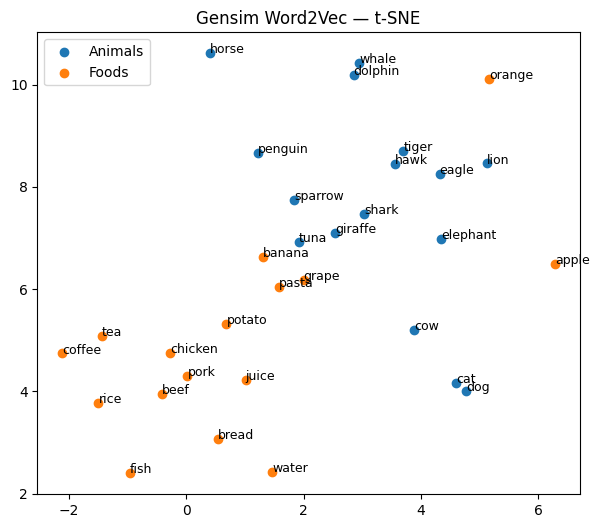

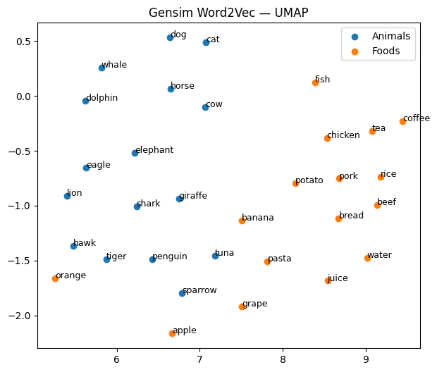

```python
X_a, y_a, l_a = collect_vectors_matrix(animals, gs_embeddings, gs_word2idx, 0)
X_f, y_f, l_f = collect_vectors_matrix(foods, gs_embeddings, gs_word2idx, 1)

X = X_a + X_f
y = y_a + y_f
labels = l_a + l_f

X_tsne = run_tsne(X)
plot_2d(X_tsne, y, labels, "Gensim Word2Vec — t-SNE")

X_umap = run_umap(X)
plot_2d(X_umap, y, labels, "Gensim Word2Vec — UMAP")
```

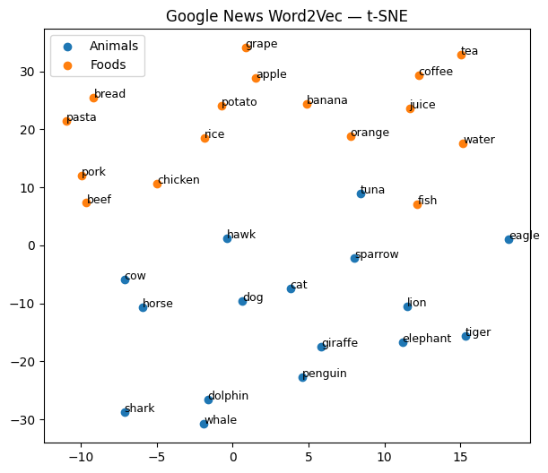

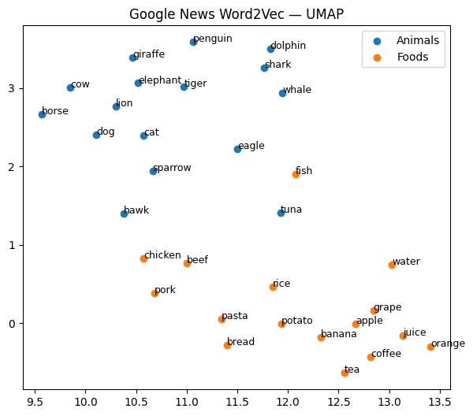

```python
import gensim
gn = gensim.models.keyedvectors.KeyedVectors.load(
    "word2vec-google-news-300.model",
    mmap="r"
)
X_a, y_a, l_a = collect_vectors_kv(animals, gn, 0)
X_f, y_f, l_f = collect_vectors_kv(foods, gn, 1)

X = X_a + X_f
y = y_a + y_f
labels = l_a + l_f

X_tsne = run_tsne(X)
plot_2d(X_tsne, y, labels, "Google News Word2Vec — t-SNE")

X_umap = run_umap(X)
plot_2d(X_umap, y, labels, "Google News Word2Vec — UMAP")
```

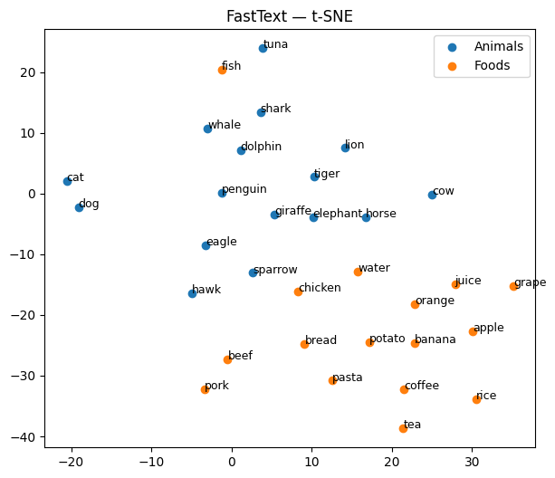

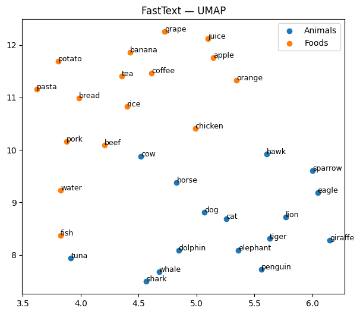

```python
ft = gensim.models.keyedvectors.KeyedVectors.load(
    "fasttext-wiki-news-subwords-300.model",
    mmap="r"
)

X_a, y_a, l_a = collect_vectors_kv(animals, ft, 0)
X_f, y_f, l_f = collect_vectors_kv(foods, ft, 1)

X = X_a + X_f
y = y_a + y_f
labels = l_a + l_f

X_tsne = run_tsne(X)
plot_2d(X_tsne, y, labels, "FastText — t-SNE")

X_umap = run_umap(X)
plot_2d(X_umap, y, labels, "FastText — UMAP")
```

## Short Answer Questions

### Which embeddings performed best at capturing sentence meaning?

The Gensim-trained Word2Vec performed moderately well:

- It captured some synonym relationships (e.g., cat ↔︎ feline) better than the PyTorch model.
- However, clusters were less compact and sometimes overlapped.

The PyTorch-trained Word2Vec performed the weakest:

- Sentence similarity was driven mostly by direct word overlap (e.g., presence of cat).
- Synonym-based sentences received low similarity scores.
- In visualizations, animals and foods showed weaker separation and more overlap, indicating less robust semantic representations.

### Were the pretrained embeddings significantly better than your own? Why or why not?

Yes, the pretrained embeddings were significantly better than the embeddings trained from scratch.

Reasons:

- Pretrained models were trained on massive corpora (billions of tokens), allowing them to learn rich semantic relationships and rare word associations.
- They captured synonymy, relatedness, and category structure much more effectively than models trained on a smaller dataset.
- In contrast, the PyTorch and Gensim models were trained on a limited corpus, which restricted their ability to learn nuanced semantic patterns.

### What factors might explain the differences in performance?

Several factors explain the observed differences:

1. **Training data size and diversity**

Pretrained embeddings benefit from orders of magnitude more data than the local training corpus.

Larger datasets expose models to more contexts, synonyms, and linguistic variations.

2. **Vocabulary coverage**

Pretrained embeddings include well-trained vectors for rare or abstract words (e.g., feline, canine), while locally trained models may have weak or noisy representations for such words.

3. **Training maturity**

Pretrained models are trained for many epochs with carefully tuned hyperparameters, while the local models were trained for a fixed, relatively small number of epochs.

4. **Sentence representation method**

Sentence embeddings were computed using mean pooling, which treats all words equally.

This can cause common or stop words to dominate the sentence representation, especially in weaker embeddings.

Stronger embeddings are more robust to this limitation.

5. **Model architecture and enhancements**

FastText benefits from subword information, allowing it to represent morphologically related or rare words better than standard Word2Vec.

## Bonus Exploration

```python
#Bonus
import numpy as np
from sklearn.metrics.pairwise import cosine_similarity

def most_similar(vec, embeddings, idx2word, topk=5):
    sims = cosine_similarity(vec.reshape(1, -1), embeddings)[0]
    top_idx = np.argsort(sims)[::-1][:topk]
    return [(idx2word[i], sims[i]) for i in top_idx]
def analogy(a, b, c, embeddings, word2idx, idx2word, topk=5):
    if a not in word2idx or b not in word2idx or c not in word2idx:
        return "One or more words not in vocabulary."

    va = embeddings[word2idx[a]]
    vb = embeddings[word2idx[b]]
    vc = embeddings[word2idx[c]]

    target = vb - va + vc
    return most_similar(target, embeddings, idx2word, topk)
def analogy_kv(a, b, c, kv, topk=5):
    if not all(w in kv for w in [a, b, c]):
        return "One or more words not in vocabulary."
    return kv.most_similar(positive=[b, c], negative=[a], topn=topk)
```

```python
with open("word2vec_embeddings.pkl", "rb") as f:
    pt = pickle.load(f)

pt_embeddings = np.asarray(pt["embeddings"])
pt_word2idx = pt["word2idx"]
pt_i2w = pt["idx2word"]   # <-- THIS LINE WAS MISSING

analogy("man", "king", "woman", pt_embeddings, pt_word2idx, pt_i2w)
```

```
[('woman', np.float32(0.8051825)),
 ('king', np.float32(0.7478255)),
 ('majority', np.float32(0.4268629)),
 ('commercial', np.float32(0.4208156)),
 ('evidence', np.float32(0.41222593))]
```

```python
with open("word2vec_gensim_embeddings.pkl", "rb") as f:
    gs = pickle.load(f)

gs_embeddings = np.asarray(gs["embeddings"])
gs_word2idx = gs["word2idx"]
gs_i2w = gs["idx2word"]   # <-- THIS LINE

analogy("man", "king", "woman", gs_embeddings, gs_word2idx, gs_i2w)
```

```
[('king', np.float32(0.81005484)),
 ('queen', np.float32(0.70937526)),
 ('isabella', np.float32(0.66903555)),
 ('elizabeth', np.float32(0.65593743)),
 ('empress', np.float32(0.64966416))]
```

```python
analogy_kv("man", "king", "woman", gn)
```

```
[('queen', 0.7118193507194519),
 ('monarch', 0.6189674139022827),
 ('princess', 0.5902431011199951),
 ('crown_prince', 0.5499460697174072),
 ('prince', 0.5377321839332581)]
```

```python
analogy_kv("man", "king", "woman", ft)
```

```
[('queen', 0.7786749005317688),
 ('queen-mother', 0.7143871784210205),
 ('king-', 0.6981282234191895),
 ('queen-consort', 0.6724597811698914),
 ('monarch', 0.6666999459266663)]
```

In the analogy task man : king :: woman : ?, the pretrained Word2Vec and FastText embeddings performed best, returning queen as the top prediction with other royalty-related terms nearby. The Gensim-trained model partially captured the relation (queen ranked highly), while the PyTorch-trained embeddings failed to recover the expected analogy, indicating weaker global linear structure. These gaps are primarily explained by the much larger training corpora and stronger vocabulary coverage of pretrained embeddings, and FastText’s additional subword modeling.

## AI Use Disclosure (Required)

If you used any AI-enabled tools (e.g., ChatGPT, GitHub Copilot, Claude, or other LLM assistants) while working on this assignment, you must disclose that use here. The goal is transparency-not punishment.

In your disclosure, briefly include: - **Tool(s) used:** (name + version if known) - **How you used them:** (e.g., concept explanation, debugging, drafting code, rewriting text) - **What you verified yourself:** (e.g., reran the notebook, checked outputs/plots, checked shapes, read documentation) - **What you did *not* use AI for (if applicable):** (optional)

You are responsible for the correctness of your submission, even if AI suggested code or explanations.

- Tool(s) used: ChatGPT (OpenAI, GPT-5 family; exact version unknown)
- How I used them: I used ChatGPT to clarify conceptual questions related to Word2Vec, sentence similarity, embedding visualization, and word analogy tasks. I also used it for debugging Python/PyTorch and Google Colab issues, drafting and refining code snippets for analysis (sentence similarity, t-SNE/UMAP visualizations, analogy evaluation), and for help interpreting results and structuring explanations.
- What I verified myself: I ran all scripts and notebooks end-to-end in Google Colab. I verified that the code executed without errors, checked tensor shapes and embedding dimensions, confirmed vocabulary mappings, inspected similarity scores and visualization plots, and ensured that all outputs matched expectations. All reported results are based on code I executed and validated myself.
- What I did not use AI for (if applicable): I did not use AI tools to fabricate results or submit unverified outputs. I did not rely on AI without independently running and checking the code. I understand that I am fully responsible for the correctness of the submission.